# Stat 436 Homework-3

Peiyuan Li

2024-04-10

```r
#Hide unnecessary output and warning message such as library(tidyverse)
knitr::opts_chunk$set(warnings = FALSE, message = FALSE)
library(dplyr)
library(tidyverse)
```

```r
library(ggplot2)
library(sf)
library(raster)
library(tmap)
```

## Coding 1 Bike Demand [3 points]

### This problem asks you to visualize a dataset of hourly bikeshare demand:

```r
bike_data <- read_csv("https://uwmadison.box.com/shared/static/f16jmkkskylfl1hnd5rpslzduja929g2.csv")
head(bike_data)
```

| dteday | season | yr | mnth | hr | holiday | weekday | temp | hum | windspeed | count |
| --- | --- | --- | --- | --- | --- | --- | --- | --- | --- | --- |
| 2011-01-01 | 1 | 0 | 1 | 0 | 0 | 6 | 0.24 | 0.81 | 0.0000 | 16 |
| 2011-01-01 | 1 | 0 | 1 | 1 | 0 | 6 | 0.22 | 0.80 | 0.0000 | 40 |
| 2011-01-01 | 1 | 0 | 1 | 2 | 0 | 6 | 0.22 | 0.80 | 0.0000 | 32 |
| 2011-01-01 | 1 | 0 | 1 | 3 | 0 | 6 | 0.24 | 0.75 | 0.0000 | 13 |
| 2011-01-01 | 1 | 0 | 1 | 4 | 0 | 6 | 0.24 | 0.75 | 0.0000 | 1 |
| 2011-01-01 | 1 | 0 | 1 | 5 | 0 | 6 | 0.24 | 0.75 | 0.0896 | 1 |

### a.Make a line plot of bike demand (count) by hour, faceted out across the 7 days of the week (weekday)

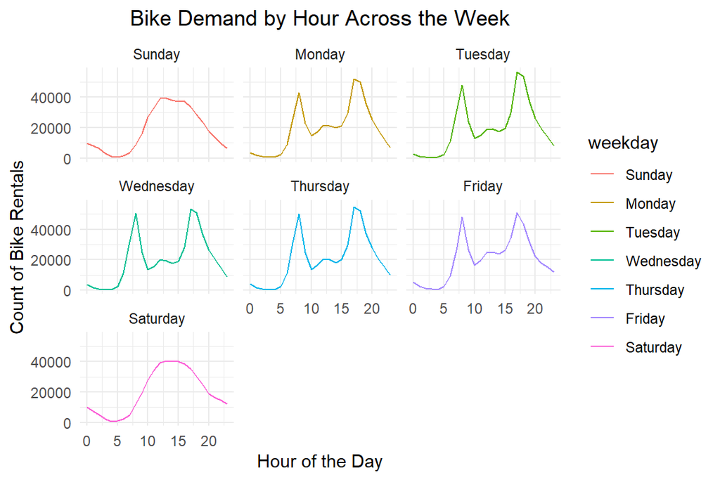

```r
#Select required data and rename them properly
q1 <- bike_data %>%
  dplyr::select(weekday, hr, count) %>%
  mutate(weekday = factor(weekday, levels = 0:6, labels = c("Sunday", "Monday", "Tuesday", "Wednesday", "Thursday", "Friday", "Saturday"))) %>%
  group_by(hr, weekday) %>%
  summarise(summary = sum(count))


# Plotting with geom_line
ggplot(q1, aes(x = hr, y = summary)) + # Ensure that we group by weekday for the line plot
  geom_line(aes(color = weekday)) +
  facet_wrap(~weekday) + # Facets for each weekday
  labs(x = "Hour of the Day", y = "Count of Bike Rentals", title = "Bike Demand by Hour Across the Week") +
  theme_minimal()+
  theme(plot.title = element_text(hjust = 0.5)) # Center the title
```

### b.Create a new summary data.frame giving the 25 and 75 percent quantiles of demand (count) for each hour (hr) by day of the week (weekday) combination, separately within each year (yr) that the data was collected

```r
q2 <- bike_data %>%
  mutate(yr = yr + 2011) %>%
  mutate(weekday = factor(weekday, levels = 0:6, labels = c("Sunday", "Monday", "Tuesday", "Wednesday", "Thursday", "Friday", "Saturday"))) %>%
  group_by(yr, weekday, hr) %>%
  summarise(
    Q25 = quantile(count, 0.25),
    Q75 = quantile(count, 0.75)
  ) %>%
  rename(year = yr, hour = hr) # Renaming the columns
q2
```

| year | weekday | hour | Q25 | Q75 |
| --- | --- | --- | --- | --- |
| 2011 | Sunday | 0 | 39.00 | 108.50 |
| 2011 | Sunday | 1 | 33.50 | 79.00 |
| 2011 | Sunday | 2 | 29.00 | 65.75 |
| 2011 | Sunday | 3 | 13.50 | 35.00 |
| 2011 | Sunday | 4 | 3.00 | 11.00 |
| 2011 | Sunday | 5 | 4.00 | 9.00 |
| 2011 | Sunday | 6 | 3.00 | 16.75 |
| 2011 | Sunday | 7 | 10.00 | 37.25 |
| 2011 | Sunday | 8 | 33.50 | 92.00 |
| 2011 | Sunday | 9 | 58.00 | 171.75 |

[output cut: 326 more lines]

### c.Using a ribbon plot, overlay the quantities from (b) onto your plot from part (a). Use color to distinguish between the ribbons for the first and second year that the data were collected

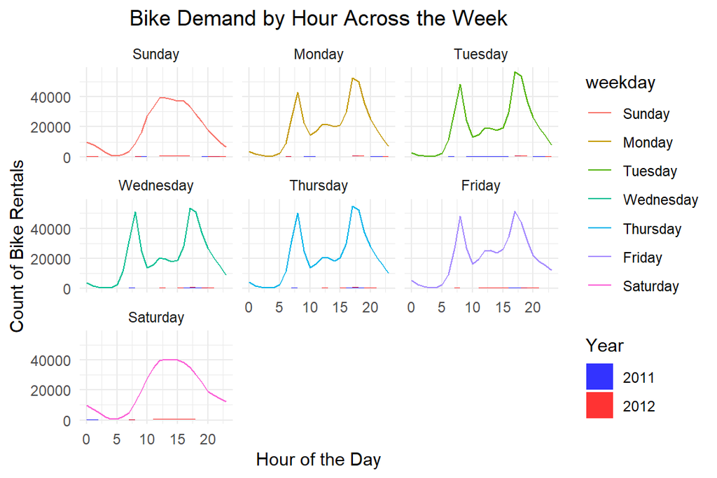

```r
# Merge the summary data with the quantile data.
# Since q2 contains summaries for each year, we will need to join this with q1 based on hr and weekday.
# Assuming that q1 has been grouped and summarised without the year, we will need to account for this.

# First, let's correct the renaming issue in the q2 data frame:
q1 <- q1 %>%
  rename(hour = hr) # Rename hr to hour

# Now let's merge q1 and q2
q3 <- q1 %>%
  ungroup() %>% # Make sure q1 is not grouped
  left_join(q2, by = c("weekday", "hour")) # Join q2 data to q1 data

# Plotting with geom_ribbon and geom_line
ggplot(q3, aes(x = hour, y = summary)) +
  geom_ribbon(aes(ymin = Q25, ymax = Q75, fill = as.factor(year)), alpha = 0.8) +
  geom_line(aes(color = weekday)) +
  facet_wrap(~weekday) + # Facets for each weekday
  scale_fill_manual(values = c("blue", "red"), name = "Year") + # Set manual colors for the ribbon based on year
  labs(x = "Hour of the Day", y = "Count of Bike Rentals", title = "Bike Demand by Hour Across the Week") +
  theme_minimal() +
  theme(plot.title = element_text(hjust = 0.5)) # Center the title and move legend to bottom
```

### d.Provide a brief description of some takeaways from the final visualization

Demand Patterns: There are clear patterns of demand based on the time of day. Demand peaks typically occur during what would be expected to be rush hours, suggesting that bike rentals are possibly used for commuting to and from work or school.

Weekday vs. Weekend: The patterns for weekdays and weekends are noticeably different. Weekends (Saturday and Sunday) tend to have a single broad peak, which could indicate leisure or errand activities that are not bound to the strict schedules of a workday.

## Coding 2 & Discussion Geospatial Datasets [3 points]

### a.NYC Building Footprints

```r
nyc_sf <-read_sf("https://uwmadison.box.com/shared/static/qfmrp9srsoq0a7oj0e7xmgu5spojr33e.geojson")
nyc_sf %>%dplyr::select(geometry)
```

| geometry |
| --- |

[output cut: 2716 more lines]

The nyc building is a .geojson file, it implies that the data is in a vector format. It contains geometries of type MultiPolygon because it is presented as <S3: sfc_MULTIPOLYGON>

### b.Africa Population 2020

```r
africa_pop <- raster("https://github.com/krisrs1128/stat436_s24/raw/main/data/afripop2020.tif")
africa_pop
```

```
## class      : RasterLayer
## dimensions : 434, 413, 179242  (nrow, ncol, ncell)
## resolution : 0.1666667, 0.1666667  (x, y)
## extent     : -17.62625, 51.20708, -34.97542, 37.35792  (xmin, xmax, ymin, ymax)
## crs        : +proj=longlat +datum=WGS84 +no_defs
## source     : afripop2020.tif
## names      : afripop2020
## values     : 0, 21181.16  (min, max)
```

This is a raster data since it stores in standard TIFF file, and it is easy to see it when we read with R has a “RasterLayer” class information

### c.Himalayan Glacial Lakes

```r
himalayan_lakes <- read_sf("https://raw.githubusercontent.com/krisrs1128/stat436_s23/main/data/GL_3basins_2015.topojson")
himalayan_lakes %>% dplyr::select(geometry)
```

| geometry |
| --- |

[output cut: 3599 more lines]

The Himalayan Glacial Lakes is a .topojson file, it implies that the data is in a vector format. It contains geometries of type Polygon because its gemoetry is presented as <S3: sfc_POLYGON>

### d.Wisconsin EV Charging

```r
wi_ev_charging <- read_sf("https://raw.githubusercontent.com/krisrs1128/stat436_s24/main/data/ev.geojson")
wi_ev_charging %>% dplyr::select(geometry)
```

| geometry |
| --- |

[output cut: 836 more lines]

### e.Zion Elevation

```r
zion_evl <- raster("https://github.com/krisrs1128/stat436_s24/raw/main/data/landsat.tif")
zion_evl
```

```
## class      : RasterLayer
## band       : 1  (of  4  bands)
## dimensions : 1428, 1128, 1610784  (nrow, ncol, ncell)
## resolution : 30, 30  (x, y)
## extent     : 301905, 335745, 4111245, 4154085  (xmin, xmax, ymin, ymax)
## crs        : +proj=utm +zone=12 +datum=WGS84 +units=m +no_defs
## source     : landsat.tif
## names      : landsat_1
## values     : 7550, 19071  (min, max)
```

This is a raster data since it stores in standard TIFF file, and it is easy to see it when we read with R has a “RasterLayer” class information

### f.Visualize one of these datasets

I will visualize e.Zion Elevation for question f

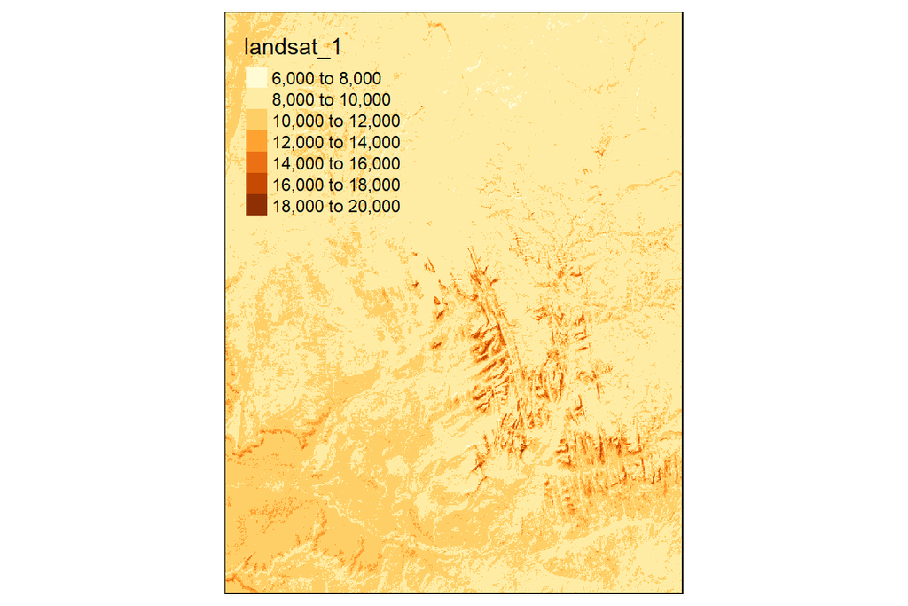

```r
tm_shape(zion_evl) +
  tm_raster()
```

## Coding3 Political Book Recommendations [4 points]

[Political Book Recommendations] In this problem, we’ll study a network dataset of Amazon bestselling US Politics books. Books are linked by an edge if they appeared together in the recommendations (“customers who bought this book also bought these other books”).

### a.The code below reads in the edges and nodes associated with the network. The edges dataset only contains IDs of co-recommended books, while the nodes data includes attributes associated with each book. Build a tbl_graph object to store the graph.

```r
library(tidygraph)
edge_data_path <- "https://raw.githubusercontent.com/krisrs1128/stat992_f23/6c4130bddbdfc9ef90537c794cdca47773643752/activities/week10/political-books-edges.csv"
node_data_path <- "https://github.com/krisrs1128/stat992_f23/raw/6c4130bddbdfc9ef90537c794cdca47773643752/activities/week10/political-books-nodes.csv"
edges <- read_csv(edge_data_path, col_types = "cci")
nodes <- read_csv(node_data_path, col_types = "ccc")
# Building the tbl_graph
book_graph <- tbl_graph(nodes = nodes, edges = edges, directed = FALSE)
book_graph
```

```
## # A tbl_graph: 105 nodes and 441 edges
## #
## # An undirected simple graph with 1 component
## #
## # Node Data: 105 × 3 (active)
##    id    label                      political_ideology
##    <chr> <chr>                      <chr>
##  1 0     1000 Years for Revenge     neutral
##  2 1     Bush vs. the Beltway       conservative
##  3 2     Charlie Wilson's War       conservative
##  4 3     Losing Bin Laden           conservative
##  5 4     Sleeping With the Devil    neutral
##  6 5     The Man Who Warned America conservative
##  7 6     Why America Slept          neutral
##  8 7     Ghost Wars                 neutral
##  9 8     A National Party No More   conservative
## 10 9     Bush Country               conservative
## # ℹ 95 more rows
## #
## # Edge Data: 441 × 3
##    from    to weight
##   <int> <int>  <int>
## 1     1     2      1
## 2     1     3      1
## 3     1     4      1
## # ℹ 438 more rows
```

### b.Use the result from part (a) to visualize the network as a node-link diagram. Include the book’s title in the node label, and shade in the node according to political ideology.

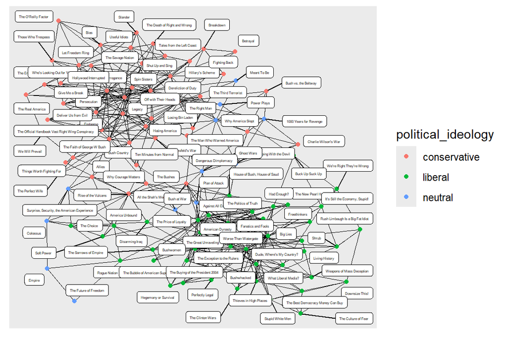

```r
library(ggraph)
ggraph(book_graph, layout = "kk") +
  geom_edge_link(width = 0.1) +
  geom_node_point(aes(color = political_ideology))+
  geom_node_label(aes(label = label), size = 1.1, repel = TRUE)
```

### c.Create the analogous adjacency matrix visualization. Provide examples of visual queries that are easy to answer using one encoding but not the other (i.e., what is easy to see in the node-link view vs. what is easy to see in the adjacency matrix).

I tried to add label on y and x axis, but there are so many data point and overlapping so i only have clean matrix graph instead of a labeled one

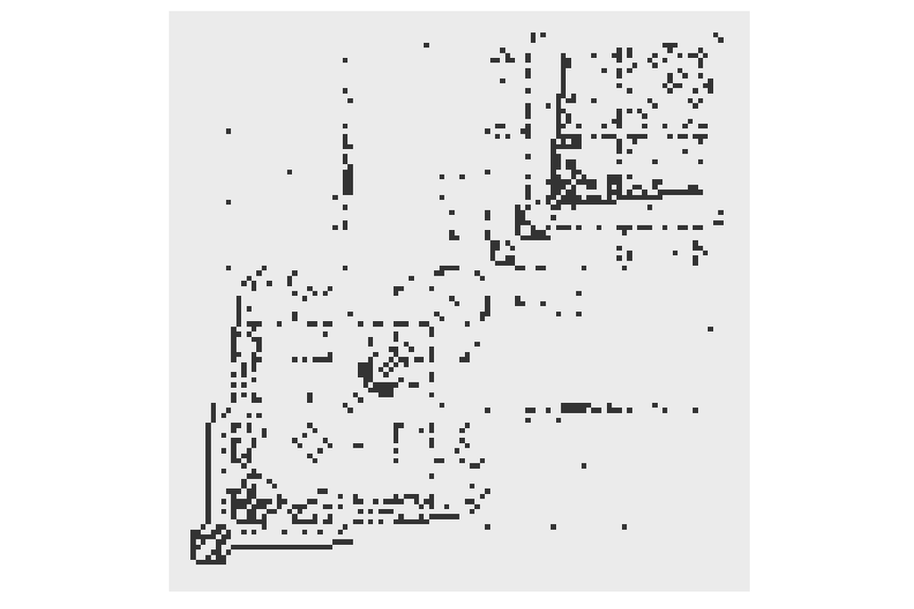

```r
ggraph(book_graph, "matrix") +
  geom_edge_tile(mirror = TRUE) + #its not directed so mirror, its ok not mirror as well
  coord_fixed() #make sure grid are square
```

What is easy to see in the node-link view: It’s easier to trace the connection between two nodes.

Example Query: Which books are recommended together with the book “All the Shah’s Men”?

What is easy to see in the adjacency matrix: It’s easier to find the density of connections around each nodes.

Example Query: Are there any books that are outliers, being recommended with only one or no other books?